# Pierini_Mignella_Vestini

2023-02-13

Before starting anything we need to set the seed and define a couple of functions.

First we defined a function to compute the Wasserstein’s distance in the case of two multivariate normal distributions with the same variance/covariance matrix.

Given a distribution N(mu1, sigma) and a value d, we will use the second function to find the increment i to apply to mu1 to get a second distribution N(mu1+i, sigma), such that the Wasserstein’s distance between the two is equal to d.

```r
# set the seed for reproducibility
set.seed(3752)


# Function to compute the Wasserstein's distance
wasserstein_sameS <- function(mu1, mu2){
  return(sum((mu1-mu2)^2))
}


# Function to find the right increment to apply to the mean to get a set
# Wasserstein distance
Find_Increment <- function(d, k){
  return(sqrt(d/k))
}
```

## **3**

### **GOODNESS-OF-FIT**

The goodness-of-fit problem occurs when we have a data set $\{x_i\}_{i=1}^{N}$ and we have to figure out whether the density distribution $p(x)$ of the data set is the same as the one of the given distribution $p_0(x)$.

Continuing the explanation given in the summary of Friedman’s paper, for the goodness-of-fit procedure we need to build the $H_0(t)$ distribution. To do so we need to:

Here is the function used for the implementation of the procedure.

```r
# Function that implements the Friedman's procedure for the goodness-of-fit problem
simul_GOF <- function(n0, n1, mu1, mu2, sigma, alpha){
  # Samples
  x <- mvrnorm(n0, mu = mu1, Sigma = diag(sigma))
  z <- mvrnorm(n1, mu = mu2, Sigma = diag(sigma))

  # labels
  label <- c(rep(0, n0), rep(1, n1))

  # Put them together with the respectives labels
  u <- cbind(rbind(x, z), Label = label)

  # Monte Carlo simulation size to find the H_0(t) distribution
  N <- 500

  # Vector to save the test statistics
  stats <- rep(NA, N)

  # Simulation
  for(i in (1:N)){
    # Get a new sample distributed as x (under H_0)
    z_t <- mvrnorm(n1, mu = mu1, Sigma = diag(sigma))
    # And put them together
    u_t <- rbind(x, z_t)

    # Set the labels
    u_t <- cbind(u_t, Label = label)

    # First thing to do is train the model
    model <- glm(Label ~ ., data = as.data.frame(u_t))
    # Get the scores from the model
    score <- predict(model, as.data.frame(u_t))

    # Get the test statistic using the scores of the trained model
    stats[i] <- ks.test(score[1:n0], score[(n0+1):(n0+n1)], alternative = "two.sided")$statistic
  }

  # Train the model with the actual data
  model <- glm(Label ~ ., data = as.data.frame(u))
  # Get the scores
  score <- predict(model, as.data.frame(u))

  # Return whether or not the hypothesis was rejected
  # by checking if the statistic is under the 1-alpha quantile of the H_0 distribution
  return(ks.test(score[1:n0], score[(n0+1):(n0+n1)], alternative = "two.sided")$statistic < quantile(stats, 1 - alpha))
}
```

For our simulations we are going to change different parameters:

- The sample sizes: $n_0$ and $n_1$.
- The number of features: $k$.

Here we will report the codes just for the first simulation, for the following ones we are going to report only the results.

```r
# Sample size
n0 <- 33
n1 <- 40
# Number of features
k <- 3
# Simulation size
P <- 100

# Initializations

# Distances between the distributions
dist <- seq(0, 1, 0.1)
# Increments to achieve the distances
grid <- sapply(dist, Find_Increment, k = k)
# Store the results
result <- c()
# Store the Power
POWER <- matrix(NA, 11, 2)
# Size of the test
alpha <- 0.05

# Mean of the first distribution
mu1 <- runif(k, 0, 1)
# Main diagonal for the variance/covariance matrix
sigma <- runif(k, 0, 1)

# Parallel
cl <- makeCluster(detectCores())

for(l in (1:11)){
  # Mean of the second distribution
  mu2 <- mu1 + rep(grid[l], k)
  clusterExport(cl, c("simul_GOF", "mvrnorm", "n0", "n1", "mu2", "mu1", "alpha", "sigma"))
  # Friedman's procedure
  result <- c(result, parallel::parSapply(cl, seq(1, P), function(.) simul_GOF(n0, n1, mu1, mu2, sigma, alpha)))
}
stopCluster(cl)

result <- matrix(result, nrow = P)

# Store the distance and the power
for(i in (1:11)){
  POWER[i,1] <- wasserstein_sameS(mu1,mu1+rep(grid[i],k))
  POWER[i,2] <- sum(result[,i]==F)/P
}
```

#### **First simulation: $n_0 = 33$, $n_1 = 40$ and $k = 3$.**

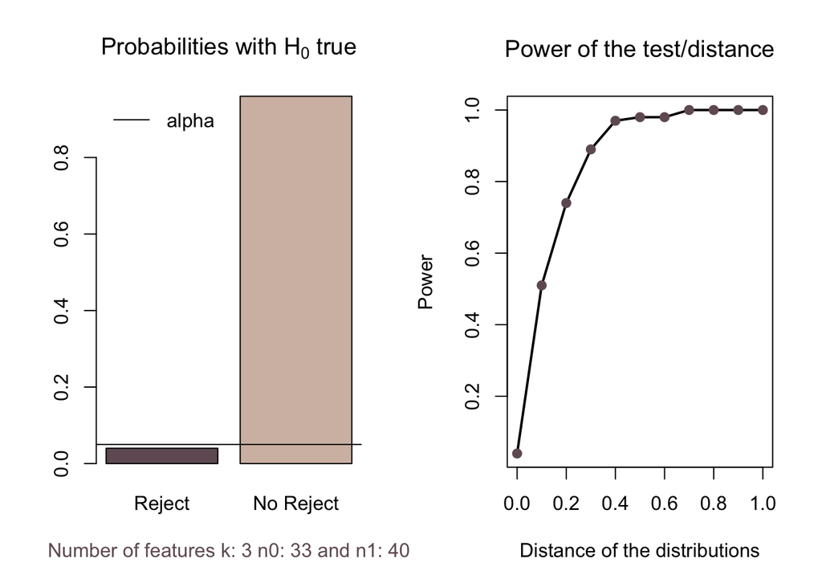

#### **Second simulation: $n_0 = 33$, $n_1 = 40$ and $k = 20$.**

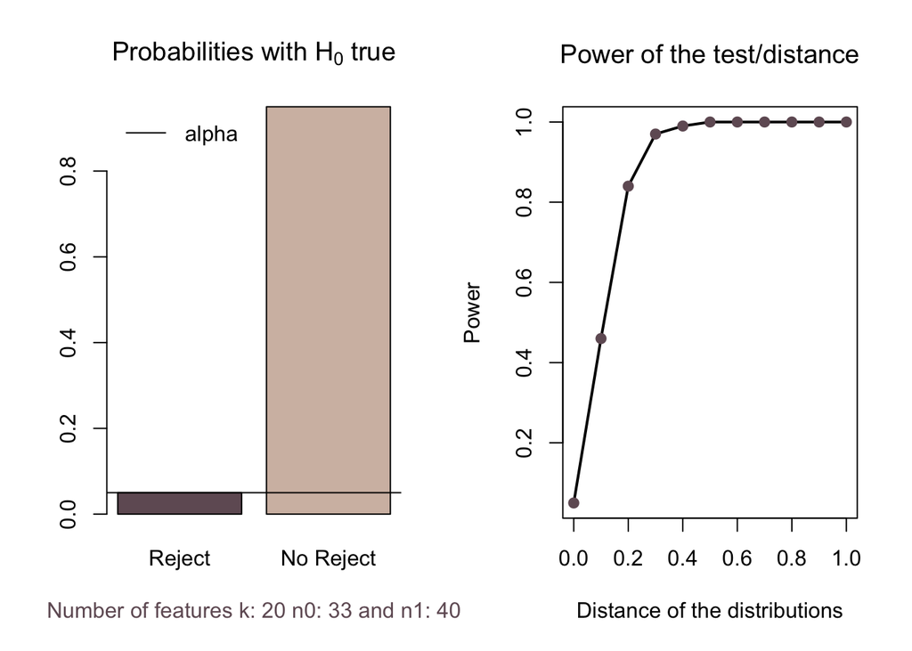

#### **Third simulation: $n_0 = 94$, $n_1 = 90$ and $k = 3$.**

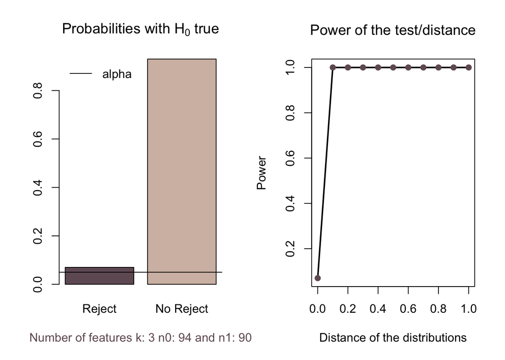

#### **Fourth simulation: $n_0 = 94$, $n_1 = 90$ and $k = 20$.**

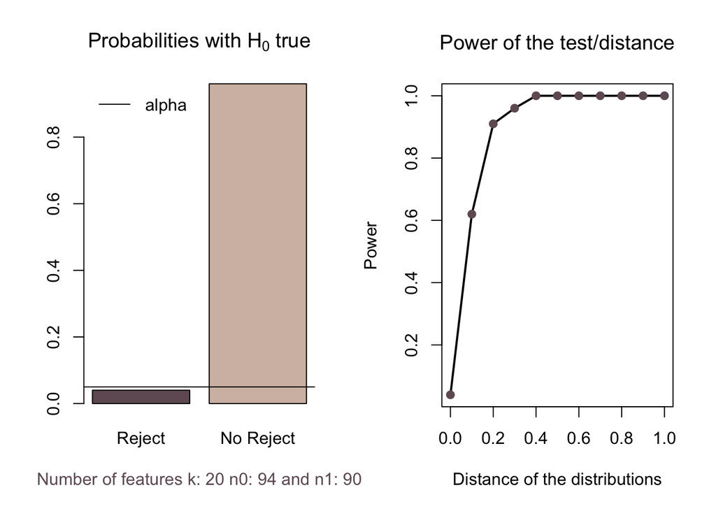

As we can see from the plots above (the left ones): chosen the value $\alpha = 0.05$ under the null hypothesis we obtain that the size of the test ($P('reject \ H_0'|'H_0 \ is \ True')$) is around the value of $\alpha$.

About the power ($P('reject \ H_0'|'H_0 \ is \ False')$) instead, from the plots on the right we can see:

- It increases with the distance between the distributions.
- It increases with the number of samples $N = n_0 + n_1$.

### **TWO-SAMPLE-TESTING**

The two-sample testing problem, instead, occurs when we have two different data sets, $\{x_i\}_{i=1}^{N}$ drawn from $p(x)$ and $\{z_i\}_{i=1}^{M}$ drawn from $q(z)$, and we have the goal to test if $p = q$.

Also in this case we will continue the explanation given in the summary of Friedman’s paper. For the two-sample testing procedure we need to build the $H_0(t)$ distribution, to do so we need to:

Here is the function used for the implementation of the procedure.

```r
# Function that implements the Friedman's procedure two-sample-testing problem
simul_TST <- function(mu1, mu2, n0, n1, sigma, alpha){
  # Get the two samples
  x <- mvrnorm(n0, mu = mu1, Sigma = diag(sigma))
  z <- mvrnorm(n1, mu = mu2, Sigma = diag(sigma))
  # Set the labels
  label <- c(rep(0, n0), rep(1, n1))
  # And put everything together
  u <- cbind(rbind(x, z), Label = label)

  # 'Monte Carlo' simulation size
  P <- 500
  # Vector to save the test statistics
  t_l <- rep(NA, P)

  # Simulation
  for(i in (1:P)){
    # Pertutate the labels
    l <- sample(label, n0 + n1)
    # Put the samples together with the permutated labels
    u_t <- rbind(cbind(x, Label = l[1:n0]), cbind(z, Label = l[(n0+1):(n0+n1)]))

    # Train the model on the permutated data set
    model <- glm(Label ~ ., data = as.data.frame(u_t))
    # Get the model's scores
    score <- predict(model, as.data.frame(u_t))

    # Find and save the test statistic computed on the scores
    t_l[i] <- ks.test(score[l == 0], score[l == 1])$statistic
  }

  # Train the model on the original data and label
  model <- glm(Label ~ ., data = as.data.frame(u))
  # Get the score
  score <- predict(model, as.data.frame(u))

  # Return whether or not the test statistic is under the 1 - alpha quantile
  # Or in other words whether or not we reject the hypothesis
  return(ks.test(score[1:n0], score[(n0+1):(n0+n1)])$statistic < quantile(t_l, 1 - alpha))
}
```

For our simulations we are going to change different parameters:

- The sample sizes: $n_0$ and $n_1$.
- The number of features: $k$.

Here we will report the codes just for the first simulation, for the following ones we are going to report only the results.

#### **First simulation: $n_0 = 33$, $n_1 = 40$ and $k = 3$.**

```r
# Sample size
n0 <- 33
n1 <- 40
# Number of features
k <- 3
# Simulation size
P <- 100

# Initializations

# Distances between the distributions
dist <- seq(0, 0.5, 0.05)
# Increments to achieve the distances
grid <- sapply(dist, Find_Increment, k = k)
# Store the results
result <- c()
# Store the Power
POWER <- matrix(NA, 11, 2)
# Size of the test
alpha <- 0.05

# Mean of the first distribution
mu1 <- runif(k, 0, 1)
# Main diagonal for the variance/covariance matrix
sigma <- runif(k, 0, 1)

# Parallel
cl <- makeCluster(detectCores())

for(l in (1:11)){
  # Mean of the second distribution
  mu2 <- mu1 + rep(grid[l], k)
  clusterExport(cl, c("simul_TST", "mvrnorm", "n0", "n1", "mu2", "mu1", "alpha", "sigma"))
  # Friedman's procedure
  result <- c(result, parallel::parSapply(cl, seq(1, P), function(.) simul_TST(mu1, mu2, n0, n1, sigma, alpha)))
}
stopCluster(cl)

result <- matrix(result, nrow = P)
# Store the distance and the power
for(i in (1:11)){
  POWER[i,1] <- wasserstein_sameS(mu1,mu1+rep(grid[i],k))
  POWER[i,2] <- sum(result[,i]==F)/P
}
```

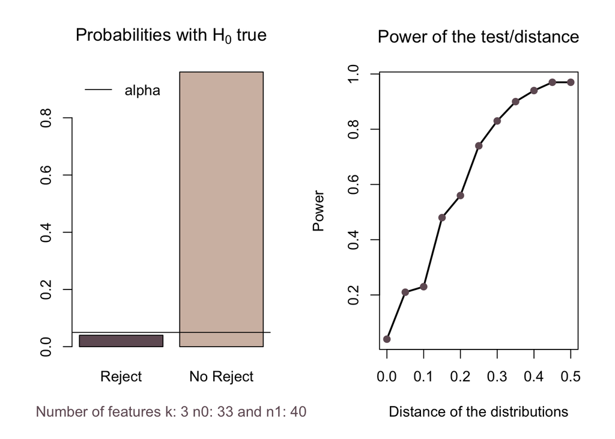

#### **Second simulation: $n_0 = 33$, $n_1 = 40$ and $k = 20$.**

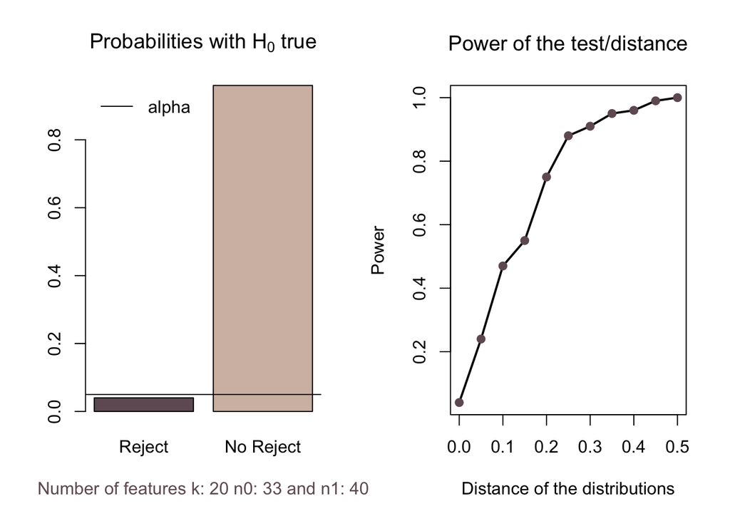

#### **Third simulation: $n_0 = 94$, $n_1 = 90$ and $k = 3$.**

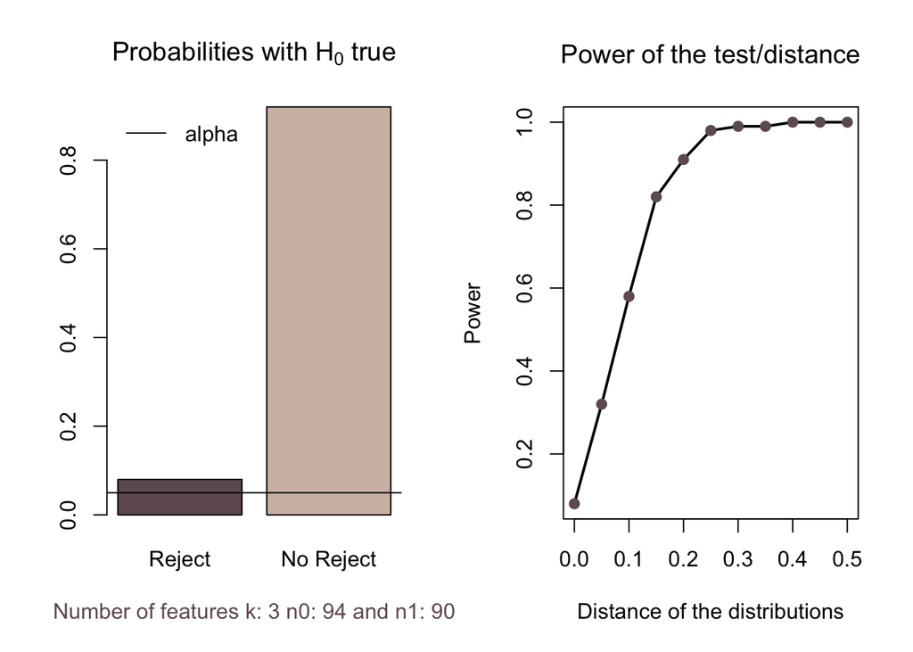

#### **Fourth simulation: $n_0 = 94$, $n_1 = 90$ and $k = 20$.**

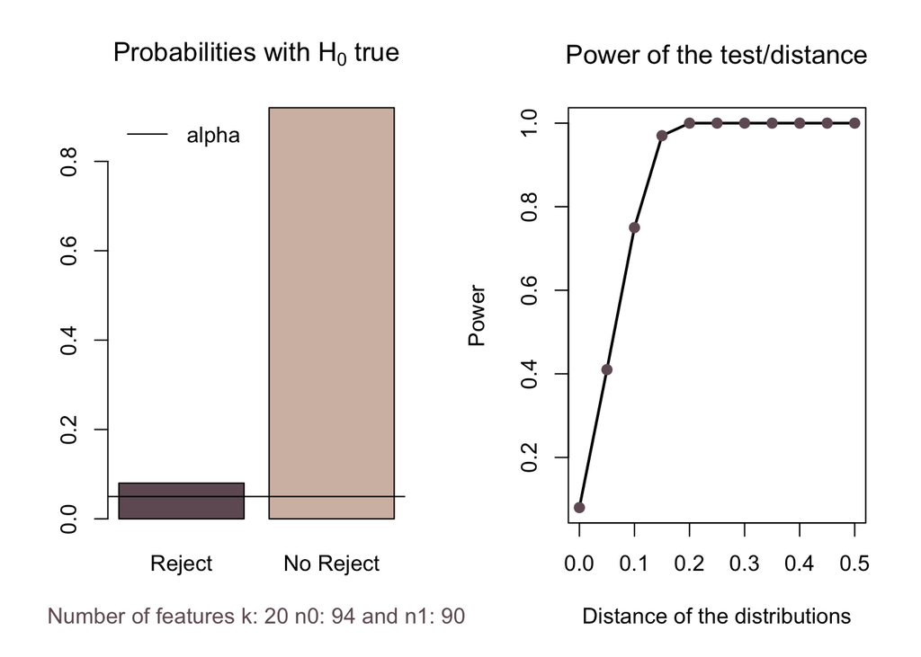

## **4**

#### **The data.**

```r
# Load the data
load('hw3_data.Rdata')
```

We can now see that the file contained two different list, of length 85 and 93 respectively, one for each group of patients:

- The data of the patients with the Autism Spectrum Disorder, are going to be contained in the “asd_sel” list.
- The data of the Typically Developed patients, are going to be contained in the “td_sel” list.

In both cases, each element of the lists contains a data frame of different sizes (Mx116), where 116 represent the different ROIs and M the number of observations in time, that is different for each patient.

#### **Pre-processing**

After loading the data we can take a look inside it.

Here are the first 10 observations in time of the ROI 2001 of the patient caltech_0051472:

```
##  [1]  0.016220  0.640587  1.219444  1.238555  0.683578  0.032254 -0.281328
##  [8] -0.296564 -0.370402 -0.677666
```

And the ones of the patient trinity_0050234:

```
##  [1]    16.89461  -151.77333  -660.06824 -1286.52612 -1485.25745  -909.00568
##  [7]   154.32582   984.41943  1110.37524   725.44208
```

We can notice that there is variability in the data, that is caused by the fact that the observations came from different labs.

So to deal with this we decided to standardize on a lab basis. To do so, we will compute the mean and standard deviation over the labs, then for each patient of the lab we will subtract from their time series (all 116 of them) this mean and divide by the standard deviation.

```r
# Put the data together
data <- c(asd_data, td_data)

# Get the initial of the labs
lab <- names(data)
iniziali <- c()
for(name in lab) {
  iniziali <- c(iniziali, substr(name,1,2))
}

# And take the unique ones
iniziali_unique <- unique(iniziali)

# Iterate over initials
for(start in iniziali_unique){
  elements <- c()
  # Select the indexes of the patients of the lab
  idx <- seq(1:length(iniziali))[iniziali == start]
  # Compute mean
  mu <- mean(unlist(data[idx]))
  # And standard deviation
  s <- sd(unlist(data[idx]))

  # Standardize
  for(i in idx){
    patient <- data[[i]]
    for(j in (1:116)){
      patient[[j]] <- (patient[[j]]-mu)/s
    }
    data[[i]] <- patient
  }
}

# Save the standardized data
asd_st <- data[1:85]
td_st <- data[86:178]
```

### **Analysis.**

Now that the data is standardized by lab, we can start working with it, what we are going to do is extract from each time-series the following statistic summary:

- Mean.
- Standard Deviation.
- $1^{st}$ quartile.
- $2^{nd}$ quartile, or median.
- $3^{rd}$ quartile.

So we will have 5 features for each ROI.

```r
# Number of features
k <- 5

asd <- c()

# Select all the informations and save them
for(i in (1:length(asd_st))){
  paziente <- asd_st[[i]]
  for(j in (1:116)){
    p <- paziente[[j]]
    # Collect al the statistic summaries
    asd <- c(asd, mean(p))
    asd <- c(asd, sd(p))
    asd <- c(asd, quantile(p, 0.25))
    asd <- c(asd, median(p))
    asd <- c(asd, quantile(p, 0.75))
  }
}
# Put the data in matrix form
asd <- t(matrix(asd, nrow = 116*k))


td <- c()

# Select all the informations and save them
for(i in (1:length(td_st))){
  paziente <- td_st[[i]]
  for(j in (1:116)){
    p <- paziente[[j]]
    td <- c(td, mean(p))
    td <- c(td, sd(p))
    td <- c(td, quantile(p, 0.25))
    td <- c(td, median(p))
    td <- c(td, quantile(p, 0.75))
  }
}
# Put the data in matrix form
td <- t(matrix(td, nrow = 116*k))

# Put the data together with the labels
u <- cbind(rbind(asd, td), Label = c(rep(1, length(asd_data)), rep(0, length(td_data))))
```

Now we will try and use the Two-Sample-Testing procedure on our data, to check:

1. If the ASD and TD patients are distributed in the same way.
2. To confirm that the procedure does indeed work, if it doesn’t reject $H_0$ with both samples coming from ASD.

Again we will leave the code only for the first, since the procedure is the same.

```r
# Size of the original data frames
n0 <- 85
n1<- 93

# Simulation size
P <- 200

# ASD patients w/o labels
x <- u[(1:n0),(1:(k*116))]
# TD patients w/o labels
z <- u[(n0+1):(n0+n1),(1:(k*116))]

t_l <- rep(NA, P)
# Actual labels
label <- c(rep(0, n0), rep(1, n1))

# Simulation
for(i in (1:P)){
  # Permutate the labels
  l <- sample(label, n0 + n1)
  # Put the samples together with the permutated labels
  u_t <- rbind(cbind(x, Label = l[1:n0]), cbind(z, Label = l[(n0+1):(n0+n1)]))
  # Train the model on the permutated data set
  model <- glmnet(u_t[,(1:(k*116))], l, family = "gaussian", maxit = 100, alpha = 0.2)
  # Get the model's scores
  score <- predict(model, u_t[,(1:(k*116))], s = 0.5)
  # Find and save the test statistic computed on the scores
  t_l[i] <- ks.test(as.numeric(score[l == 0]), as.numeric(score[l == 1]))$statistic
}
```

#### **First: Data from ASD ($n_0 = 85$) and TD ($n_1 = 93$).**

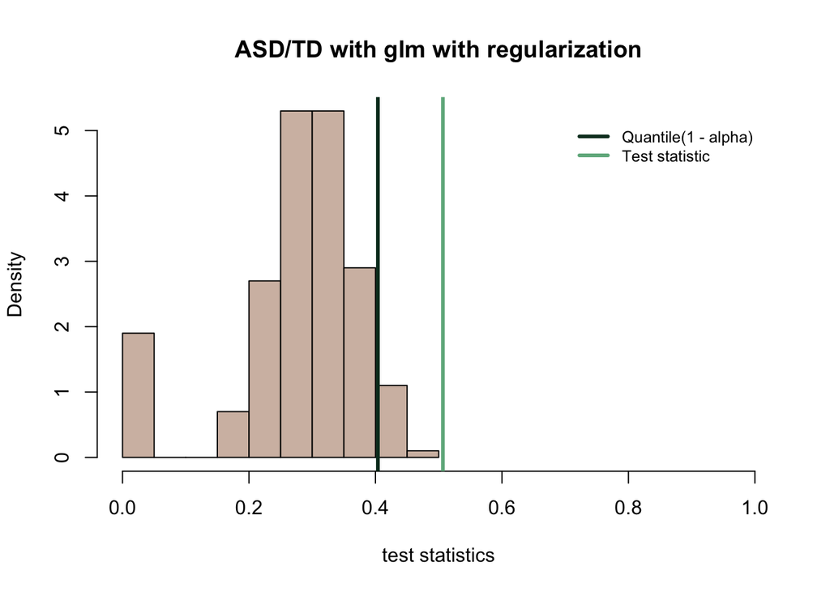

#### **Second: Data from ASD ($n_0 = 50$) and ASD ($n_1 = 35$).**

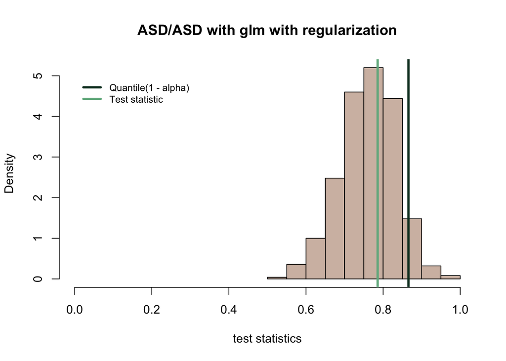

In the first plot we can notice that, by applying the Friedman’s procedure, we were able to recognize that the data coming from the patients are distributed in two different ways according to their group.

In fact, we can see that the test statistic (light green) coming from the actual data is over the $1 - \alpha$ quantile of the distribution of the test statistics, and as we know we have to reject the $H_0$ hypothesis.

Instead in the second case we have an opposite result, as expected given the fact that we are using samples coming from the same group. The test statistic coming from the actual data is under the $1 - \alpha$ quantile of the distribution of the test statistics, and this means that we can’t reject the $H_0$ hypothesis.

### **Another analysis.**

Another type of analysis that we want to underline is how the ROIs of the two groups evolve in the time series, so we actually are going to base our study on the auto-correlations.

What we are going to do is extract each ROIs’ time series, compute it’s auto-correlation and extract the same statistic summaries as previously.

So, again, for each time-series we decided to extract the following statistic summary:

- Mean.
- Standard Deviation.
- $1^{st}$ quartile.
- $2^{nd}$ quartile, or median.
- $3^{rd}$ quartile.

```r
# Number of features
k <- 5

asd <- c()

# Select all the informations and save them
for(i in (1:length(asd_st))){
  paziente <- asd_st[[i]]
  for(j in (1:116)){
    if(length(unique(paziente[[j]])) != 1)
      # Get the autocorrelation if the values of the time series are not all the same
      p <- acf(paziente[[j]], lag = length(paziente[[j]]), type = "correlation", pl = F)$acf
    else
      # Else put a vector of all 1s
      p <- rep(1, length(paziente[[j]]) - 1)
    # Collect al the statistic summaries
    asd <- c(asd, mean(p))
    asd <- c(asd, sd(p))
    asd <- c(asd, quantile(p, 0.25))
    asd <- c(asd, median(p))
    asd <- c(asd, quantile(p, 0.75))
  }
}
# Put the data in matrix form
asd <- t(matrix(asd, nrow = 116*k))


td <- c()

# Select all the informations and save them
for(i in (1:length(td_st))){
  paziente <- td_st[[i]]
  for(j in (1:116)){
    if(length(unique(paziente[[j]])) != 1)
      # Get the autocorrelation if the values of the time series are not all the same
      p <- acf(paziente[[j]], lag = length(paziente[[j]]), type = "correlation", pl = F)$acf
    else
      # Else put a vector of all 1s
      p <- rep(1, length(paziente[[j]]) - 1)
    # Collect al the statistic summaries
    td <- c(td, mean(p))
    td <- c(td, sd(p))
    td <- c(td, quantile(p, 0.25))
    td <- c(td, median(p))
    td <- c(td, quantile(p, 0.75))
  }
}
# Put the data in matrix form
td <- t(matrix(td, nrow = 116*k))

# Put the data together with the labels
u <- cbind(rbind(asd, td), Label = c(rep(1, length(asd_data)), rep(0, length(td_data))))
```

Also in this case we are going to use the Two-Sample-Testing procedure and check:

1. If the ASD and TD patients are distributed in the same way.
2. If it doesn’t reject $H_0$ with both samples coming from ASD.

#### **First: Data from ASD ($n_0 = 85$) and TD ($n_1 = 93$).**

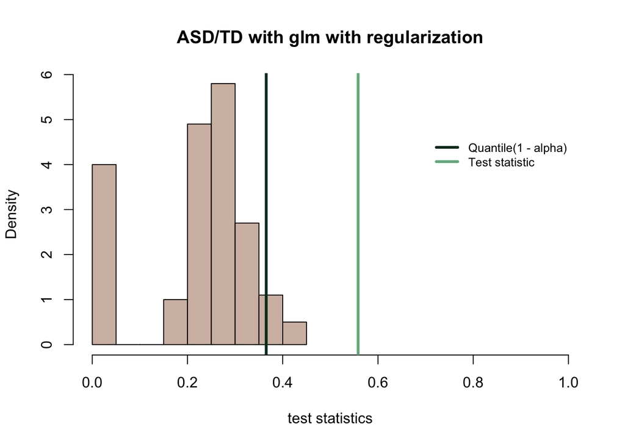

#### **Second: Data from ASD ($n_0 = 50$) and ASD ($n_1 = 35$).**

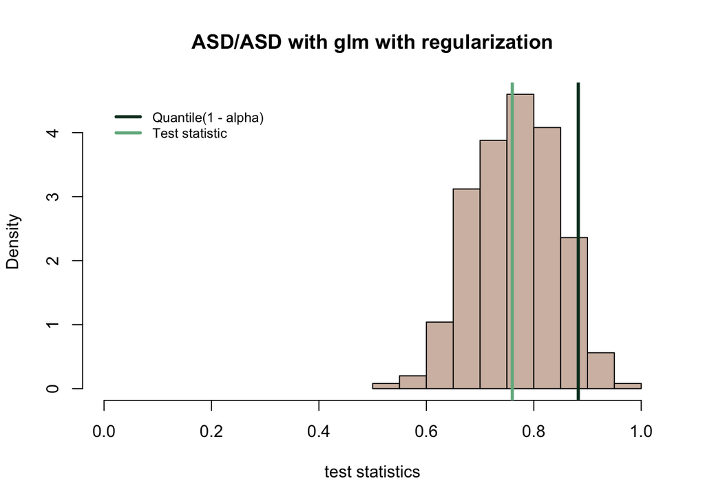

The results we obtained with this “new” analysis are consistent with the ones got before.

So, given what we saw, we can assume that there is an actual difference in the distributions of the data coming from the ASD and TD patients.